# GLMM Analysis Report

## Methods

Model was fitted using **lme4::glmer**.

Family: **binomial**

Formula: **AVAL ~ ARMCD + AGE_cs + TIMEYEAR_cs + ADHERE_cs + SEX + RACE + BSEVRITY + (1+TIMEYEAR_cs || USUBJID)**

Sample size used in this fit: **280 subjects**, **1400 observations**.

## Model Fitting Diagnostics

This section reports diagnostics captured automatically at fit time and should be reviewed before interpreting the results below. A singular fit, a non-convergence message, or fitting warnings do not necessarily invalidate a model, but they do mean its estimates (particularly variance components) should be interpreted with caution.

| Check | Result |
| --- | --- |
| Singular fit | NO |
| Convergence | OK |

### Warnings raised during model fitting

*No warnings were raised while fitting this model.*

## Results

### Model Summary

Full summary output of the fitted model, as printed by R.

```
## Generalized linear mixed model fit by maximum likelihood (Laplace Approximation) ['glmerMod']
##  Family: binomial  ( logit )
## Formula: AVAL ~ ARMCD + AGE_cs + TIMEYEAR_cs + ADHERE_cs + SEX + RACE +
##     BSEVRITY + (1 + TIMEYEAR_cs || USUBJID)
##    Data: df
## Control: glmerControl(optimizer = "bobyqa", optCtrl = list(maxfun = 2e+05))
##
##       AIC       BIC    logLik -2*log(L)  df.resid
##    1694.3    1757.2    -835.1    1670.3      1388
##
## Scaled residuals:
##     Min      1Q  Median      3Q     Max
## -2.1184 -0.6555 -0.4206  0.8118  2.7575
##
## Random effects:
##  Groups    Name        Variance Std.Dev.
##  USUBJID   (Intercept) 0.69497  0.8337
##  USUBJID.1 TIMEYEAR_cs 0.01125  0.1061
## Number of obs: 1400, groups:  USUBJID, 280
##
## Fixed effects:
##                                Estimate Std. Error z value Pr(>|z|)
## (Intercept)                    0.159174   0.389407   0.409   0.6827
## ARMCDSTDCARE                  -1.104134   0.188798  -5.848 4.97e-09 ***
## AGE_cs                         0.160123   0.080858   1.980   0.0477 *
## TIMEYEAR_cs                    0.559095   0.067129   8.329  < 2e-16 ***
## ADHERE_cs                      0.080312   0.068656   1.170   0.2421
## SEXM                           0.087236   0.165632   0.527   0.5984
## RACEBLACK OR AFRICAN AMERICAN  0.344941   0.309723   1.114   0.2654
## RACEOTHER                      0.006432   0.368521   0.017   0.9861
## RACEWHITE                      0.346454   0.282037   1.228   0.2193
## BSEVRITY                      -0.287533   0.105063  -2.737   0.0062 **
## ---
## Signif. codes:  0 '***' 0.001 '**' 0.01 '*' 0.05 '.' 0.1 ' ' 1
##
## Correlation of Fixed Effects:
##             (Intr) ARMCDS AGE_cs TIMEYE ADHERE SEXM   RACOAA RACEOT RACEWH
## ARMCDSTDCAR -0.241
## AGE_cs      -0.055 -0.032
## TIMEYEAR_cs  0.023 -0.145  0.050
## ADHERE_cs   -0.007  0.194 -0.023  0.002
## SEXM        -0.197  0.022  0.012  0.012 -0.010
## RACEBLACOAA -0.577  0.016  0.069  0.020 -0.010  0.102
## RACEOTHER   -0.446  0.027  0.040 -0.006 -0.019  0.003  0.597
## RACEWHITE   -0.576 -0.054  0.018  0.023 -0.015  0.026  0.778  0.652
## BSEVRITY    -0.702  0.168  0.036 -0.062 -0.026 -0.012 -0.014 -0.044 -0.058
```

### Random Effects

Random-effects variance components

| Group | Effect | Variance | Std.Dev. |
| --- | --- | --- | --- |
| USUBJID | (Intercept) | 0.69500 | 0.8337 |
| USUBJID.1 | TIMEYEAR_cs | 0.01125 | 0.1061 |

*For non-Gaussian GLMMs the random-effects variances are on the link (latent) scale, and there is no separate residual variance.*

### Fixed Effects

Fixed Effects

Estimate

Std. Error

z value

Pr(>|z|)

(Intercept)

0.159

0.389

0.409

0.6827

ARMCDSTDCARE

-1.104

0.189

-5.848

<1e-04

***

AGE_cs

0.160

0.081

1.980

0.0477

TIMEYEAR_cs

0.559

0.067

8.329

<1e-04

***

ADHERE_cs

0.080

0.069

1.170

0.2421

SEXM

0.087

0.166

0.527

0.5984

RACEBLACK OR AFRICAN AMERICAN

0.345

0.310

1.114

0.2654

RACEOTHER

0.006

0.369

0.017

0.9861

RACEWHITE

0.346

0.282

1.228

0.2193

BSEVRITY

-0.288

0.105

-2.737

0.0062

```
## Analysis of Variance Table
##             npar Sum Sq Mean Sq F value
## ARMCD          1 27.780  27.780 27.7799
## AGE_cs         1  3.637   3.637  3.6372
## TIMEYEAR_cs    1 82.544  82.544 82.5436
## ADHERE_cs      1  1.353   1.353  1.3531
## SEX            1  0.143   0.143  0.1434
## RACE           3  2.757   0.919  0.9190
## BSEVRITY       1  7.853   7.853  7.8533
```

### Model Performance

Variance explained and clustering (R2, ICC)

| Metric | Value |
| --- | --- |
| R2 marginal (fixed effects only) | 0.1445 |
| R2 conditional (fixed + random effects) | 0.2937 |
| ICC (adjusted) | 0.1744 |
| ICC (unadjusted) | 0.1492 |

Information criteria and error measures

| Metric | Value |
| --- | --- |
| AIC | 1.694e+03 |
| AICc | 1.694e+03 |
| BIC | 1.757e+03 |
| RMSE | 4.076e-01 |
| Sigma | 1.000e+00 |
| Log_loss | 5.051e-01 |
| Score_spherical | 1.042e-03 |

**How to read these measures**

- **R2 marginal**: proportion of variance explained by the fixed effects alone.
- **R2 conditional**: proportion of variance explained by the fixed and random effects together.
- **ICC**: proportion of the total (non-fixed-effect) variance attributable to differences between groups/subjects; higher values mean observations within the same group are more alike.
- For non-Gaussian GLMMs, R2 and ICC are computed on the latent (link) scale, so they are not directly comparable to Gaussian-model values.

### DHARMa Residual Diagnostics

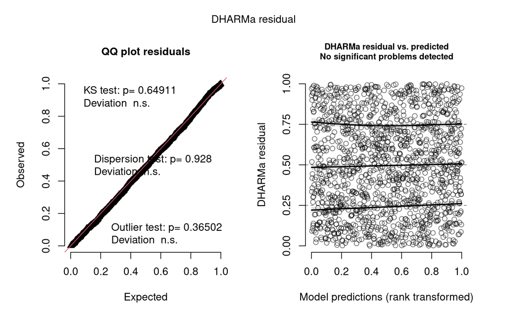